# Hotel Booking Cancellation Prediction

Observation: Plotting the threshold

```
              precision    recall  f1-score   support

           0       0.93      0.57      0.71     17073
           1       0.51      0.92      0.66      8319

    accuracy                           0.69     25392
   macro avg       0.72      0.75      0.68     25392
weighted avg       0.80      0.69      0.69     25392
```

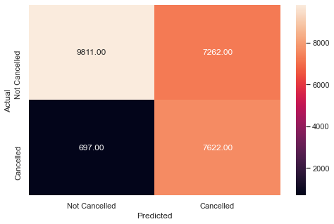

```python
y_pred_train_svm = model.predict_proba(X_train_scaled)
metrics_score(y_train, y_pred_train_svm[:,1]>optimal_threshold_svm)
```

Observation: Checking model performance on training set

```
              precision    recall  f1-score   support

           0       0.93      0.66      0.77      7317
           1       0.56      0.90      0.69      3566

    accuracy                           0.74     10883
   macro avg       0.75      0.78      0.73     10883
weighted avg       0.81      0.74      0.74     10883
```

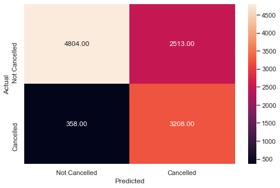

```python
y_pred_test = svm_rbf.predict_proba(X_test_scaled)
metrics_score(y_test, y_pred_test[:,1]>optimal_threshold_svm)
```

Observation: Checking model performance on test set

```python
model_dt = DecisionTreeClassifier(random_state=1)
model_dt.fit(X_train, y_train)
```

```
DecisionTreeClassifier(random_state=1)
```

Observation: Build a Decision Tree Model

```
              precision    recall  f1-score   support

           0       0.99      1.00      1.00     17073
           1       1.00      0.99      0.99      8319

    accuracy                           0.99     25392
   macro avg       1.00      0.99      0.99     25392
weighted avg       0.99      0.99      0.99     25392
```

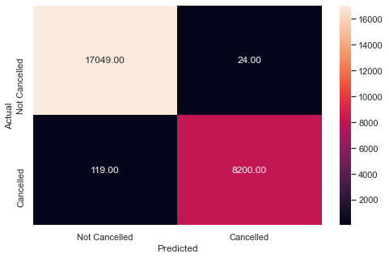

```python
pred_train_dt = model_dt.predict(X_train)
metrics_score(y_train, pred_train_dt)
```

Observation: Checking performance on the training dataset

```
              precision    recall  f1-score   support

           0       0.90      0.90      0.90      7317
           1       0.79      0.79      0.79      3566

    accuracy                           0.87     10883
   macro avg       0.85      0.85      0.85     10883
weighted avg       0.87      0.87      0.87     10883
```

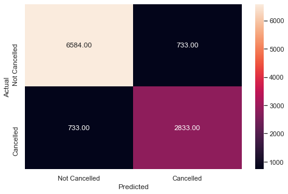

```python
pred_test_dt = model_dt.predict(X_test)
metrics_score(y_test, pred_test_dt)
```

Observation: Checking model performance on test set

```python
estimator = DecisionTreeClassifier(random_state=1)

parameters = {
    "max_depth": np.arange(1,100,10),
    "max_leaf_nodes": [50, 75, 150, 250],
    "min_samples_split": [10, 30, 50, 70],
}
grid_obj = GridSearchCV(estimator, parameters, cv=5,scoring='recall',n_jobs=-1)
grid_obj = grid_obj.fit(X_train, y_train)

estimator = grid_obj.best_estimator_

estimator.fit(X_train, y_train)
```

```
DecisionTreeClassifier(max_depth=11, max_leaf_nodes=250, min_samples_split=10,
                       random_state=1)
```

Observation: Perform hyperparameter tuning for the decision tree model using GridSearch CV

```
              precision    recall  f1-score   support

           0       0.91      0.93      0.92     17073
           1       0.85      0.81      0.83      8319

    accuracy                           0.89     25392
   macro avg       0.88      0.87      0.87     25392
weighted avg       0.89      0.89      0.89     25392
```

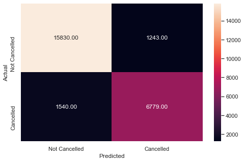

```python
dt_tuned = estimator.predict(X_train)
metrics_score(y_train,dt_tuned)
```

Observation: Checking performance on the training set

```
              precision    recall  f1-score   support

           0       0.90      0.92      0.91      7317
           1       0.82      0.78      0.80      3566

    accuracy                           0.87     10883
   macro avg       0.86      0.85      0.85     10883
weighted avg       0.87      0.87      0.87     10883
```

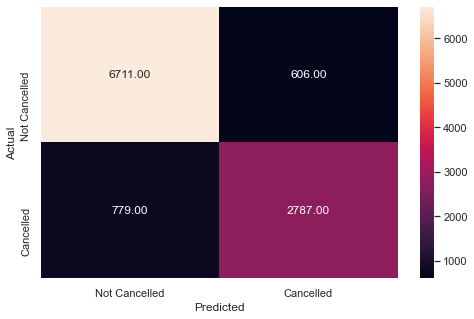

```python
y_pred_tuned = estimator.predict(X_test)
metrics_score(y_test,y_pred_tuned)
```

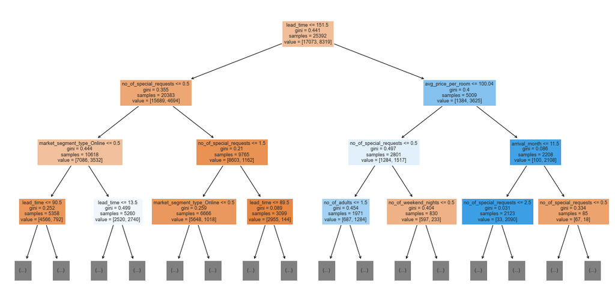

```python
feature_names = list(X_train.columns)
plt.figure(figsize=(20, 10))
out = tree.plot_tree(
    estimator,max_depth=3,
    feature_names=feature_names,
    filled=True,
    fontsize=9,
    node_ids=False,
    class_names=None,
)
for o in out:
    arrow = o.arrow_patch
    if arrow is not None:
        arrow.set_edgecolor("black")
        arrow.set_linewidth(1)
plt.show()
```

Observation: Visualizing the Decision Tree

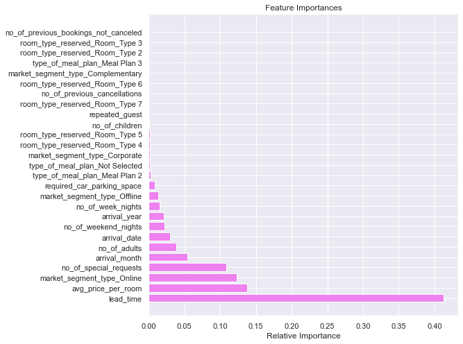

```python
importances = estimator.feature_importances_
indices = np.argsort(importances)[::-1]

plt.figure(figsize=(8, 8))
plt.title("Feature Importances")
plt.barh(range(len(indices)), importances[indices], color="violet", align="center")
plt.yticks(range(len(indices)), [feature_names[i] for i in indices])
plt.xlabel("Relative Importance")
plt.show()
```

Observation: Importance of features in the tree building

```python
rf_estimator = RandomForestClassifier( random_state = 1)

rf_estimator.fit(X_train, y_train)
```

```
RandomForestClassifier(random_state=1)
```

Observation: Build a Random Forest Model

```
              precision    recall  f1-score   support

           0       0.99      1.00      1.00     17073
           1       1.00      0.99      0.99      8319

    accuracy                           0.99     25392
   macro avg       0.99      0.99      0.99     25392
weighted avg       0.99      0.99      0.99     25392
```

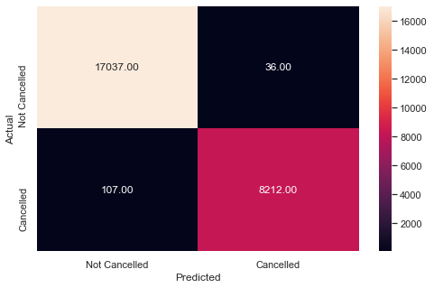

```python
y_pred_train_rf = rf_estimator.predict(X_train)

metrics_score(y_train, y_pred_train_rf)
```

Observation: Check the performance of the model on the train data

```
              precision    recall  f1-score   support

           0       0.91      0.95      0.93      7317
           1       0.88      0.80      0.84      3566

    accuracy                           0.90     10883
   macro avg       0.90      0.88      0.88     10883
weighted avg       0.90      0.90      0.90     10883
```

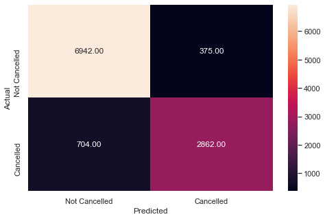

```python
y_pred_test_rf = rf_estimator.predict(X_test)

metrics_score(y_test, y_pred_test_rf)
```

Observation: Check the performance of the model on the test data

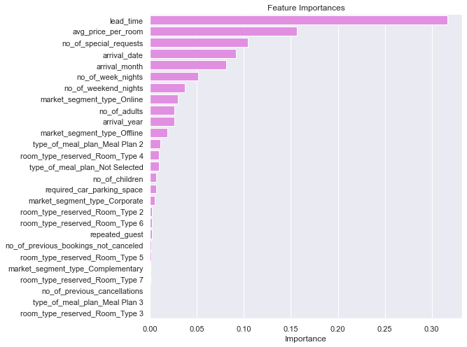

```python
importances = rf_estimator.feature_importances_

columns = X_train.columns

importance_df = pd.DataFrame(importances, index = columns, columns = ['Importance']).sort_values(by = 'Importance', ascending = False)


plt.figure(figsize=(8, 8))
plt.title("Feature Importances")
sns.barplot(importance_df.Importance, importance_df.index,color="violet")
```

Observation: Check the feature importance of the Random Forest

Four Key Takeaways for Business Recommendations:

1. When implementing a new strategy, external factors, such as the number of advertizations, lower prices, should also be carefully considered as our analysis shows that the customers who have been followed up when cancelling the Hotel Booking.
2. Closer to the fall time, there are fewer cancellations compared to the other seasons of the year.
3. Lower prices for the rates of the rooms and better quality of living will decrease the percentage of the amount of people that will cancel their hotel booking.
4. Offer incentives for non-cancellation: Consider offering incentives such as discounts or complimentary amenities for guests who commit to their bookings and don't cancel. This should increase the amount of repeated guests as well.